# Volatilidad en los rendimientos de NASDAQ-100 (NQ=F)

Análisis mediante modelo GARCH

Emilio Correa Dávola

correa42609@estudiantes.untref.edu.ar

UNTreF

2025-09-11

## Pasos previos

### Objetivos

- **Analizar la volatilidad** de una serie de tiempo de frecuencia moderada o alta.
- **Modelar** mediante la familia **GARCH** y **capturar** comportamientos complejos y asimétricos.
- Período de análisis extenso: **2015-2024**.

### Hipótesis

**Importante**

La familia de modelos **GARCH** resulta adecuada para modelar la volatilidad del NASDAQ-100 (NQ=F), logrando mayor precisión predictiva y explicando adecuadamente los clusters de volatilidad.

## Análisis exploratorio

### Visualización

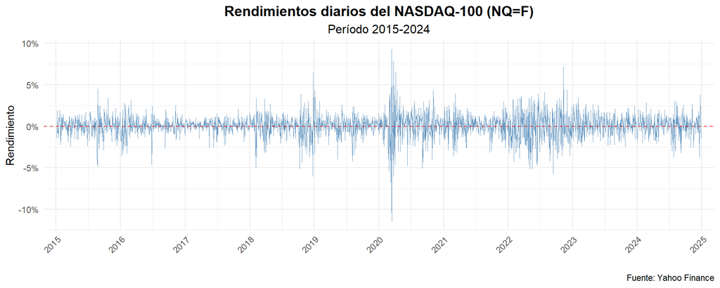

Figura 1

### Estadísticas Descriptivas

Tabla 1

| N | Media | Desvío Std | Mínimo | Máximo | Exc. Kurtosis¹ | Asimetría |
| --- | --- | --- | --- | --- | --- | --- |
| 2.511 | 6e-04 | 0,0138 | -0,1148 | 0,0927 | 6,36 | -0,53 |

¹ Exceso de Kurtosis = K - 3

### Densidad de Rendimientos vs Normal

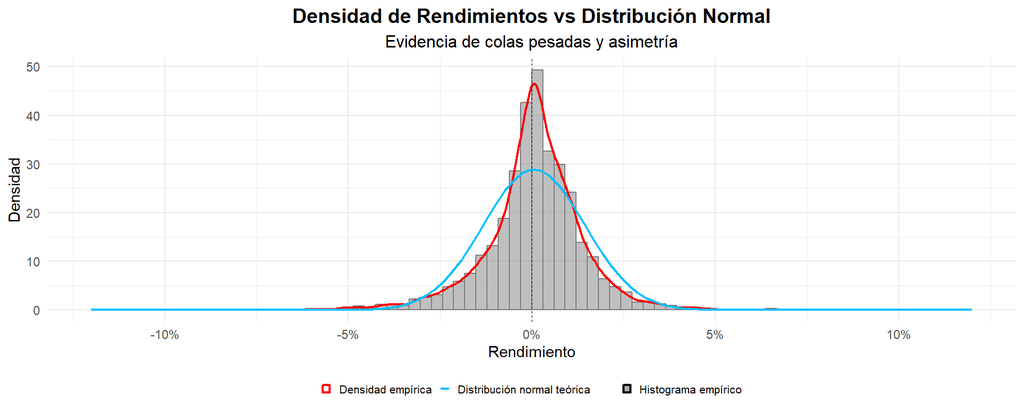

Figura 2

### Evolución de Exceso de Kurtosis y Asimetría

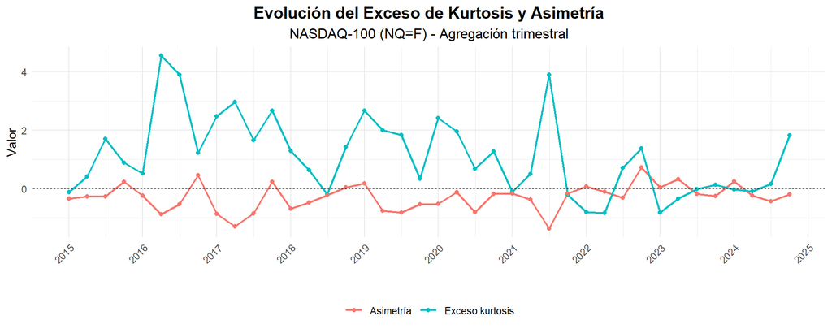

Figura 3

## Análisis exploratorio (2)

### Análisis de Autocorrelación

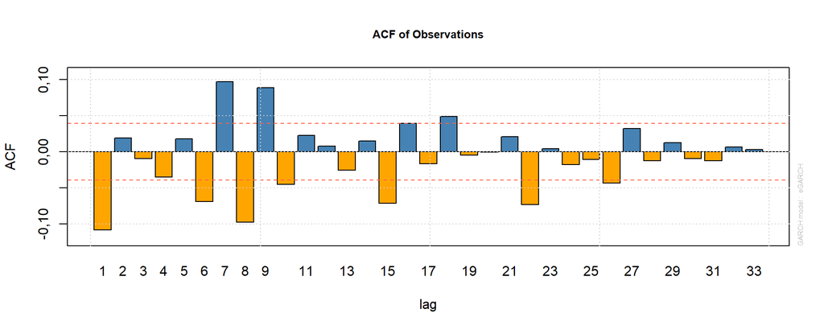

Figura 4

### Autocorrelación de Rendimientos al Cuadrado

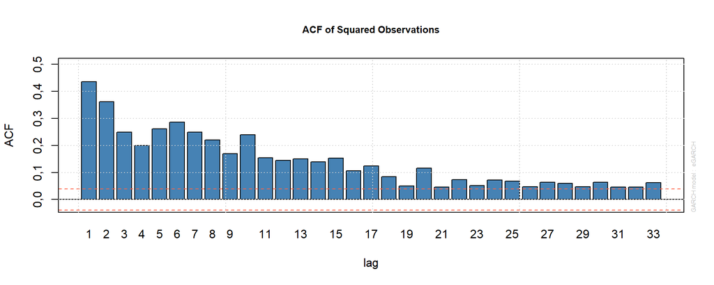

Figura 5

### Autocorrelación de Valores Absolutos

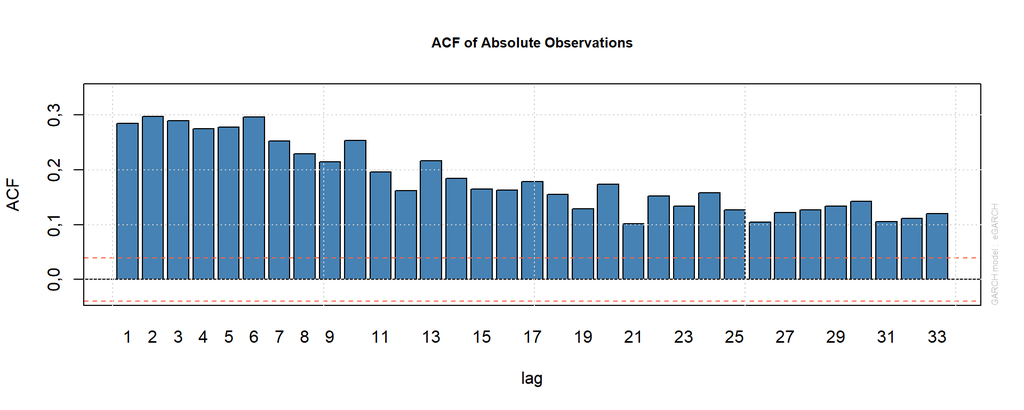

Figura 6

### Pruebas de Heterocedasticidad (ARCH)

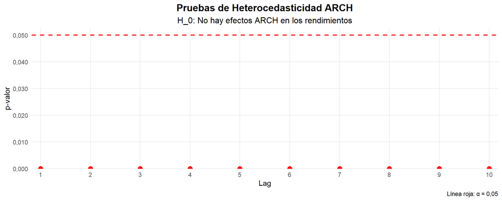

Figura 7